# CDC Well-Being Analysis

# 1 Data wrangling

## 1.1 Importing

Import the data using the SAS format.

```r
library(Hmisc)
temp_zip <- tempfile()
temp_xpt <- tempfile()
download.file("https://www.cdc.gov/brfss/annual_data/2016/files/LLCP2016XPT.zip", temp_zip)
unzip(zipfile=temp_zip, exdir=temp_xpt)
import <- sasxport.get(file.path(temp_xpt, "LLCP2016.xpt "))
```

```
Processing SAS dataset LLCP2016      ..
```

```r
unlink(temp_zip)
unlink(temp_xpt)
```

List of all columns names in the data.

```r
names(import)
```

```
  [1] "x.state"   "fmonth"    "idate"     "imonth"    "iday"      "iyear"     "dispcode"  "seqno"     "x.psu"     "ctelenm1"
 [11] "pvtresd1"  "colghous"  "stateres"  "cellfon4"  "ladult"    "numadult"  "nummen"    "numwomen"  "ctelnum1"  "cellfon5"
 [21] "cadult"    "pvtresd3"  "cclghous"  "cstate1"   "landline"  "hhadult"   "genhlth"   "physhlth"  "menthlth"  "poorhlth"
 [31] "hlthpln1"  "persdoc2"  "medcost"   "checkup1"  "exerany2"  "sleptim1"  "cvdinfr4"  "cvdcrhd4"  "cvdstrk3"  "asthma3"
 [41] "asthnow"   "chcscncr"  "chcocncr"  "chccopd1"  "havarth3"  "addepev2"  "chckidny"  "diabete3"  "diabage2"  "lastden3"
 [51] "rmvteth3"  "sex"       "marital"   "educa"     "renthom1"  "numhhol2"  "numphon2"  "cpdemo1"   "veteran3"  "employ1"
 [61] "children"  "income2"   "internet"  "weight2"   "height3"   "pregnant"  "deaf"      "blind"     "decide"    "diffwalk"
 [71] "diffdres"  "diffalon"  "smoke100"  "smokday2"  "stopsmk2"  "lastsmk2"  "usenow3"   "ecigaret"  "ecignow"   "alcday5"
 [81] "avedrnk2"  "drnk3ge5"  "maxdrnks"  "flushot6"  "flshtmy2"  "pneuvac3"  "tetanus"   "fall12mn"  "fallinj2"  "seatbelt"
 [91] "drnkdri2"  "hadmam"    "howlong"   "hadpap2"   "lastpap2"  "hpvtest"   "hplsttst"  "hadhyst2"  "pcpsaad2"  "pcpsadi1"
[101] "pcpsare1"  "psatest1"  "psatime"   "pcpsars1"  "bldstool"  "lstblds3"  "hadsigm3"  "hadsgco1"  "lastsig3"  "hivtst6"
[111] "hivtstd3"  "hivrisk4"  "pdiabtst"  "prediab1"  "insulin"   "bldsugar"  "feetchk2"  "doctdiab"  "chkhemo3"  "feetchk"
[121] "eyeexam"   "diabeye"   "diabedu"   "painact2"  "qlmentl2"  "qlstres2"  "qlhlth2"   "medicare"  "hlthcvr1"  "delaymed"
[131] "dlyother"  "nocov121"  "lstcovrg"  "drvisits"  "medscost"  "carercvd"  "medbill1"  "medadvic"  "undrstnd"  "written"
[141] "caregiv1"  "crgvrel1"  "crgvlng1"  "crgvhrs1"  "crgvprb2"  "crgvpers"  "crgvhous"  "crgvmst2"  "crgvexpt"  "cimemlos"
[151] "cdhouse"   "cdassist"  "cdhelp"    "cdsocial"  "cddiscus"  "ssbsugr2"  "ssbfrut2"  "calrinfo"  "marijana"  "usemrjna"
[161] "asthmage"  "asattack"  "aservist"  "asdrvist"  "asrchkup"  "asactlim"  "asymptom"  "asnoslep"  "asthmed3"  "asinhalr"
[171] "imfvplac"  "hpvadvc2"  "hpvadsht"  "shingle2"  "numburn2"  "cncrdiff"  "cncrage"   "cncrtyp1"  "csrvtrt1"  "csrvdoc1"
[181] "csrvsum"   "csrvrtrn"  "csrvinst"  "csrvinsr"  "csrvdein"  "csrvclin"  "csrvpain"  "csrvctl1"  "profexam"  "lengexam"
[191] "pcpsade1"  "pcdmdecn"  "sxorient"  "trnsgndr"  "rcsgendr"  "rcsrltn2"  "casthdx2"  "casthno2"  "emtsuprt"  "lsatisfy"
[201] "qlactlm2"  "useequip"  "qstver"    "qstlang"   "mscode"    "x.ststr"   "x.strwt"   "x.rawrake" "x.wt2rake" "x.chispnc"
[211] "x.crace1"  "x.cprace"  "x.cllcpwt" "x.dualuse" "x.dualcor" "x.llcpwt2" "x.llcpwt"  "x.rfhlth"  "x.phys14d" "x.ment14d"
[221] "x.hcvu651" "x.totinda" "x.michd"   "x.ltasth1" "x.casthm1" "x.asthms1" "x.drdxar1" "x.exteth2" "x.alteth2" "x.denvst2"
[231] "x.prace1"  "x.mrace1"  "x.hispanc" "x.race"    "x.raceg21" "x.racegr3" "x.race.g1" "x.ageg5yr" "x.age65yr" "x.age80"
[241] "x.age.g"   "htin4"     "htm4"      "wtkg3"     "x.bmi5"    "x.bmi5cat" "x.rfbmi5"  "x.chldcnt" "x.educag"  "x.incomg"
[251] "x.smoker3" "x.rfsmok3" "x.ecigsts" "x.curecig" "drnkany5"  "drocdy3."  "x.rfbing5" "x.drnkwek" "x.rfdrhv5" "x.flshot6"
[261] "x.pneumo2" "x.rfseat2" "x.rfseat3" "x.drnkdrv" "x.rfmam2y" "x.mam5021" "x.rfpap33" "x.rfpsa21" "x.rfblds3" "x.col10yr"
[271] "x.hfob3yr" "x.fs5yr"   "x.fobtfs"  "x.crcrec"  "x.aidtst3"
```

Select the useful columns from the data and remove any records with NA’s.

```r
# These are the names of the fields we are taking from the CDC data.
data = import[c('avedrnk2', 'alcday5', 'smokday2', 'x.ageg5yr', 'physhlth', 'sex')]
# Rename the columns to more useful and readable names (same order as above).
colnames(data) <- c('average_drinks_per_day_drank',
                    'days_in_last_30_had_a_drink',
                    'smoking_frequency',
                    'demographic_generation',
                    'physically_healthy_days_in_last_30',
                    'sex')
```

Let’s take a look at some simple statistics for each field.

NOTE: No preprocessing or cleaning has been performed on the data yet.

```r
summary(data)
```

```
 average_drinks_per_day_drank days_in_last_30_had_a_drink smoking_frequency demographic_generation
 Min.   : 1.00                Min.   :101.0               Min.   :1.00      Min.   : 1.00
 1st Qu.: 1.00                1st Qu.:202.0               1st Qu.:2.00      1st Qu.: 5.00
 Median : 2.00                Median :230.0               Median :3.00      Median : 8.00
 Mean   : 3.56                Mean   :527.3               Mean   :2.43      Mean   : 7.82
 3rd Qu.: 3.00                3rd Qu.:888.0               3rd Qu.:3.00      3rd Qu.:11.00
 Max.   :99.00                Max.   :999.0               Max.   :9.00      Max.   :14.00
 NA's   :249223               NA's   :18348               NA's   :282147
 physically_healthy_days_in_last_30      sex
 Min.   : 1.00                      Min.   :1.000
 1st Qu.:15.00                      1st Qu.:1.000
 Median :88.00                      Median :2.000
 Mean   :60.72                      Mean   :1.568
 3rd Qu.:88.00                      3rd Qu.:2.000
 Max.   :99.00                      Max.   :9.000
 NA's   :3
```

```r
nrow(data)
```

```
[1] 486303
```

## 1.2 Cleaning and preprocessing

### 1.2.1 Removing useless and empty answers

Ignore NAs in ‘average_drinks_per_day_drank’ as that variable encodes both missing and zero values as NA.

```r
data = data[!with(data, is.na(days_in_last_30_had_a_drink) |
                        is.na(smoking_frequency) |
                        is.na(demographic_generation) |
                        is.na(physically_healthy_days_in_last_30)), ]
```

Remove people who reported any question with “Don’t know” or “Refuse to answer.”

Each question encodes such answers differently:

```r
data = subset(data, !(average_drinks_per_day_drank %in% c(77, 99)))
data = subset(data, !(days_in_last_30_had_a_drink %in% c(777, 999)))
data = subset(data, !(smoking_frequency %in% c(7, 9)))
data = subset(data, demographic_generation != 14)
data = subset(data, !(physically_healthy_days_in_last_30 %in% c(77, 99)))
```

#### 1.2.1.1 Physical health

An answer encoded as 88 indicates that the person has no unhealthy days. Recode such answers to 0.

The answers to this question are encoded as number of unhealthy days. To transform the answers to be number of healthy days, subtract the answers from 30.

```r
data$physically_healthy_days_in_last_30[data$physically_healthy_days_in_last_30 == 88] <- 0
data$physically_healthy_days_in_last_30 = 30 - data$physically_healthy_days_in_last_30
```

#### 1.2.1.2 Demographic generation

Remove people who are not in any of the targeted age ranges. Groups 1-10 cover ages 18-69. We’re not analyzing the health of anyone above 69 years old.

```r
data = subset(data, demographic_generation %in% c(1:10))
```

### 1.2.2 Recoding variables into groups

#### 1.2.2.1 Demographic generation

Recode age groups into demographics by joining smaller ones into larger ones:

- **Groups 1-3** (ages 18-24, 25-29, 30-34): *Millenials*.
- **Groups 4-6** (ages 35-39, 40-44, 45-49): *Generation X*.
- **Groups 7-10** (ages 50-54, 54-59, 60-64, 65-69): *Baby Boomers*.

```r
data$demographic_generation = cut(data$demographic_generation,
                                  breaks=c(-Inf, 3, 6, Inf),
                                  labels=c('Millenials', 'Generation X', 'Baby Boomers'))
```

#### 1.2.2.2 Drinking frequency

Let the objective of this section be to compute a respondent’s average number of drinks consumed per week.

This section is quite complicated. The data we’re given does not provide a straightforward to compute the average number of drinks someone consumes per week. Fortunately, this measurement can be computed using several other variables with which we are provided:

- **Average number of drinks consumed per day that a person drinks**. This variable is encoded as blank/NA for people who have not drank at all in the last month.
- **Number of days in the last 30 that a person drank at all**. This variable is encoded strangely; respondents could either answer how many days in the last week that they drank, or the amount of days in the last month that they drank.

The intuition for what we’re going to do is format each of these variables such that we can apply the equation `drinking_frequency = average_drinks_per_day_drank * days_in_last_30_had_a_drink`.

“Number of days in the last 30 that a person drank at all” is encoded somewhat strangely as follows:

1. **If the respondent answered with the number of days in the last week that they drank**, then the field takes on a value from 101-107, where subtracting 100 gives the true number of days in which the person drank.
2. **If the respondent answered with the number of days in the last month that they drank**, then the field takes on a value from 201-230, where subtracting 200 gives the true number of days in which the person drank.
3. **If the respondent did not drink at all in the last month**, then the field takes on a value of 888.

To make it easier to understand each step, let’s transform this variable into the number of times in the last month that the person drank. We can do this by:

- Subtracting 100 from case 1 and then multiplying by 4 weeks in a month to extrapolate how much the respondent drank in the last month.
- Subtracting 200 from case 2.
- Recoding case 3 as 0.

Later on, you’ll see that we care about the number of times in the last week that the person drank; however, we recoded the variable in the last step to days in the last 30 that the person drank because the name of the variable is “days_in_last_30_had_a_drink”, so it’s easier to follow the logic when naming conventions are always consistent.

```r
days = data$days_in_last_30_had_a_drink
data$days_in_last_30_had_a_drink[days == 888] <- 0
data$days_in_last_30_had_a_drink[days >= 100 & days < 200] <- (data$days_in_last_30_had_a_drink[days >= 100 & days < 200] - 100) * 4
data$days_in_last_30_had_a_drink[days >= 200 & days < 300] <- data$days_in_last_30_had_a_drink[days >= 200 & days < 300] - 200
```

Now that we have the number of days in the last 30 in which the respondent drank at all, we can apply the formula above. Note that our ultimate goal is to get the number of days in the last week in which the person drank, so we must divide the frequency by 4.

```r
data$average_drinks_per_day_drank[is.na(data$average_drinks_per_day_drank)] <- 0
data$drinking_frequency = (data$days_in_last_30_had_a_drink * data$average_drinks_per_day_drank) %/% 4
```

Now, let’s partition the respondents into three groups:

1. People who don’t drink at all.
2. People who drink, but would not be classified as alcoholics (1-8 drinks/week).
3. People who would be classified as alcoholics (9+ drinks/week).

NOTE: The official diagnoses are different for men and women, so we use the mean of the two terms to classify both genders. In the future, we may want to separate the classifications out for each gender.

```r
data$drinking_frequency = cut(data$drinking_frequency, breaks=c(-Inf, 0, 8, Inf), labels=c('None', 'Some', 'Alcoholism'))
```

For the final step, let’s remove the intermediate columns from the original dataset; they only add noise at this point.

```r
data = within(data, rm(days_in_last_30_had_a_drink, average_drinks_per_day_drank))
```

#### 1.2.2.3 Smoking frequency

Smoking frequency is encoded as follows:

1. Every day.
2. Some days.
3. Not at all.

This ordering is not very useful for analysis, so let’s re-order it as follows:

0. Not at all.
1. Some days.
2. Every day.

```r
data$smoking_frequency[data$smoking_frequency == 3] <- 0
# Swap 1 and 2 because they're in a confusing order.
data$smoking_frequency[data$smoking_frequency == 1] <- 9999
data$smoking_frequency[data$smoking_frequency == 2] <- 1
data$smoking_frequency[data$smoking_frequency == 9999] <- 2
```

Next, let’s rename the partitions from numbers, which are difficult to read, into the factors “None”, “Some Days”, and “Every Day”.

```r
data$smoking_frequency = cut(data$smoking_frequency, breaks=c(-Inf, 0, 1, Inf), labels=c('None', 'Some Days', 'Every Day'))
```

## 1.3 Write the data to a file

```r
write_data = data[sample(nrow(data), 1000), ]
write_data$demographic_generation <- as.numeric(write_data$demographic_generation)
write_data$smoking_frequency <- as.numeric(write_data$smoking_frequency)
write_data$drinking_frequency <- as.numeric(write_data$drinking_frequency)
write.csv(write_data, "data.csv")
rm(write_data)
```

# 2 Data exploration

## 2.1 High-level overview

Now that we have completed all the data wrangling and preprocessing, let’s explore the data for trends which we can spot visually.

```r
summary(data)
```

```
 smoking_frequency  demographic_generation physically_healthy_days_in_last_30      sex         drinking_frequency
 None     :84099   Millenials  :21609      Min.   : 0.0                       Min.   :1.000   None      :75887
 Some Days:16505   Generation X:32386      1st Qu.:25.0                       1st Qu.:1.000   Some      :44817
 Every Day:41305   Baby Boomers:87914      Median :30.0                       Median :2.000   Alcoholism:21205
                                           Mean   :24.4                       Mean   :1.505
                                           3rd Qu.:30.0                       3rd Qu.:2.000
                                           Max.   :30.0                       Max.   :9.000
```

```r
data
```

|  | smoking_frequency | demographic_generation | physically_healthy_days_in_last_30 | sex | drinking_frequency |
| --- | --- | --- | --- | --- | --- |
| 19 | Every Day | Generation X | 10 | 2 | Alcoholism |
| 21 | None | Generation X | 23 | 2 | None |
| 22 | None | Millenials | 26 | 2 | None |
| 24 | None | Baby Boomers | 30 | 1 | None |
| 26 | Some Days | Generation X | 30 | 1 | Some |
| 30 | None | Baby Boomers | 30 | 2 | None |
| 33 | None | Baby Boomers | 30 | 2 | Some |
| 34 | Some Days | Baby Boomers | 27 | 1 | None |
| 35 | None | Baby Boomers | 30 | 1 | None |
| 43 | Some Days | Baby Boomers | 16 | 1 | None |

[output cut: 990 more lines]

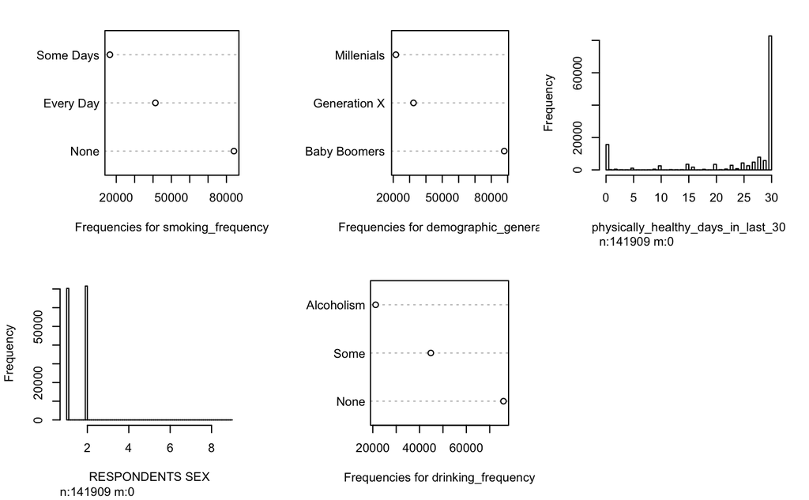

```r
hist(data)
```

## 2.2 Group means

A quick check of the healthy days group means for the categories within each predictor will tell us if there’s any merit to further analysis at all.

```r
aggregate(data$physically_healthy_days_in_last_30, list(data$drinking_frequency), mean)
```

| Group.1 | x |
| --- | --- |
| None | 22.73613 |
| Some | 26.37747 |
| Alcoholism | 26.18156 |

```r
aggregate(data$physically_healthy_days_in_last_30, list(data$smoking_frequency), mean)
```

| Group.1 | x |
| --- | --- |
| None | 25.16438 |
| Some Days | 23.65168 |
| Every Day | 23.14601 |

```r
aggregate(data$physically_healthy_days_in_last_30, list(data$demographic_generation), mean)
```

| Group.1 | x |
| --- | --- |
| Millenials | 26.70193 |
| Generation X | 25.06583 |
| Baby Boomers | 23.59046 |

```r
aggregate(data$physically_healthy_days_in_last_30, list(data$drinking_frequency, data$smoking_frequency, data$demographic_generation), mean)
```

| Group.1 | Group.2 | Group.3 | x |
| --- | --- | --- | --- |
| None | None | Millenials | 26.38840 |
| Some | None | Millenials | 27.88177 |
| Alcoholism | None | Millenials | 27.94716 |
| None | Some Days | Millenials | 25.85934 |
| Some | Some Days | Millenials | 27.07825 |
| Alcoholism | Some Days | Millenials | 27.63693 |
| None | Every Day | Millenials | 25.33728 |
| Some | Every Day | Millenials | 26.78181 |
| Alcoholism | Every Day | Millenials | 26.32345 |
| None | None | Generation X | 24.61107 |

[output cut: 17 more lines]

From the results above, it’s impossible to say whether there is an effect in each group or not; however, with our large sample size, and the substantial differences between group means, we can speculate that further analysis is promising.

```r
fit <- aov(physically_healthy_days_in_last_30 ~ drinking_frequency * smoking_frequency * demographic_generation, data)
summary(fit)
```

```
                                                                Df   Sum Sq Mean Sq  F value   Pr(>F)
drinking_frequency                                               2   452645  226322 2404.775  < 2e-16 ***
smoking_frequency                                                2   110206   55103  585.495  < 2e-16 ***
demographic_generation                                           2   179195   89597  952.012  < 2e-16 ***
drinking_frequency:smoking_frequency                             4     5040    1260   13.389 6.55e-11 ***
drinking_frequency:demographic_generation                        4    24231    6058   64.366  < 2e-16 ***
smoking_frequency:demographic_generation                         4    10979    2745   29.164  < 2e-16 ***
drinking_frequency:smoking_frequency:demographic_generation      8     2325     291    3.089  0.00174 **
Residuals                                                   141882 13353044      94
---
Signif. codes:  0 ‘***’ 0.001 ‘**’ 0.01 ‘*’ 0.05 ‘.’ 0.1 ‘ ’ 1
```

```r
drop1(fit, ~., test="F")
```

[output not shown]